# Week9

Jenna Ford

6/30/2019

## Clean and Prepare the Data

```r
#Set Libraries
library(RCurl)
library(tidyverse)
library(ggplot2)
```

```r
#Read in the Beers and Breweries Data
URL <- getURL("https://raw.githubusercontent.com/BivinSadler/MSDS-6306-Doing-Data-Science/master/Unit%209/Beers.csv")
Beers <- read.csv(text=URL)

URL1 <- getURL("https://raw.githubusercontent.com/BivinSadler/MSDS-6306-Doing-Data-Science/master/Unit%209/Breweries.csv")
Breweries <- read.csv(text=URL1)

#Create a columns for brewery ID that is common to both datasets
Beers <- Beers %>% rename(Brewery_ID = Brewery_id)
Breweries <- Breweries %>% rename(Brewery_ID = Brew_ID)

#Merge the beer and brewery datasets into a dataframe
df <- merge(Breweries,Beers, by = "Brewery_ID",all=TRUE)

#Remove extra spaces in the State column
df$State <- gsub(" ", "", df$State, fixed = TRUE)

#Create a beerCOTX dataset with only Colorado and Texas and no missing IBUs
beerCOTX <- filter(df, !is.na(IBU) & (State == 'CO' | State == 'TX'))

#Order the beerCOTX dataset by ascending IBU
beerCOTX <- beerCOTX[order(-beerCOTX$IBU),]
```

## Create a plot of ABV vs. IBU for both Colorado and Texas

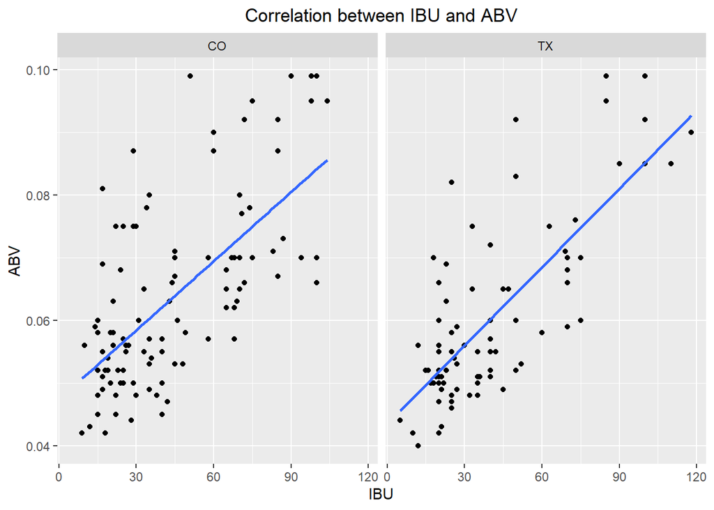

```r
ggplot(beerCOTX, aes(x=IBU, y=ABV)) +
  geom_point() +
  stat_smooth(method="lm",se=F) +
  theme(plot.title = element_text(hjust = 0.5)) +
  ggtitle("Correlation between IBU and ABV") +
  facet_wrap(~State)
```

## Model the data

Data modeling will include:

- Fit a simple linear regression model to assess the relationship between ABV and IBU for CO and TX
- Create a scatterplot with the regression line superimposed on the plot (not using ggplot)
- Address the assumptions of the regression model

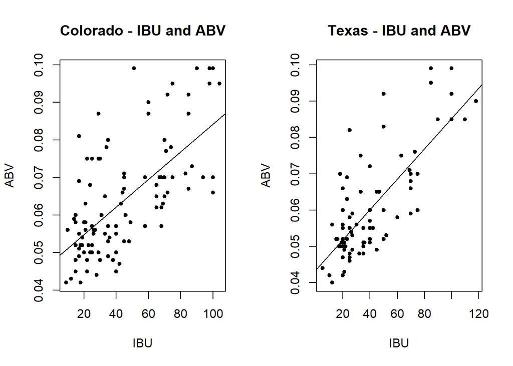

```r
#Fit simple linear regression models
modelTX <- lm(ABV ~ IBU, data=filter(beerCOTX,State=='TX'))
modelCO <- lm(ABV ~ IBU, data=filter(beerCOTX,State=='CO'))

#Plot the data and the regression lines
par(mfrow=c(1,2))
with(beerCOTX[(beerCOTX$State == 'CO'),], plot(IBU, ABV,pch=20,main="Colorado - IBU and ABV"))
abline(modelCO)

with(beerCOTX[(beerCOTX$State == 'TX'),], plot(IBU, ABV,pch=20,main="Texas - IBU and ABV"))
abline(modelTX)
```

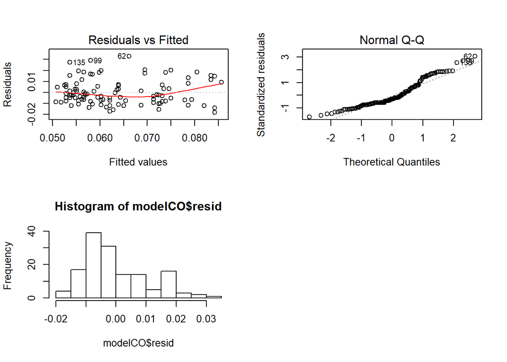

```r
#Check Assumptions for CO
par(mfrow=c(2,2))
plot(modelCO, which=1:2)
hist(modelCO$resid)
```

#### Assumptions for Colorado

1. Are the explanatory and response variables linearly related? - The data does appear to be linearly related based on the scatterplot and the randomness of the residuals in the Residuals vs Fitted plot. The p-values for the coefficients are significant, indicating there is a linear relationship.
2. Are the residuals normally distributed? - The Normal QQ plot and Histogram below show that the residuals are not normally distributed and is right-skewed.
3. Do the residuals have constant variance? - The Residuals vs Fitted plot and Histogram below show that the residuals do not have constant variance.
4. Are the datapoints independent? - I am assuming the data are independent.

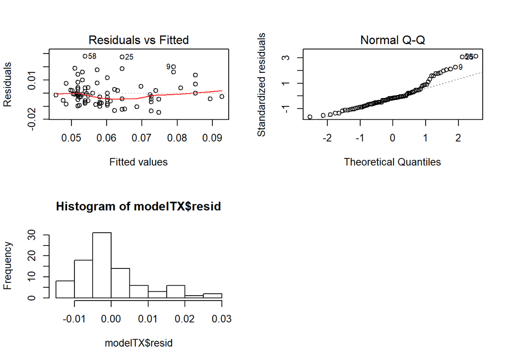

```r
#Check Assumptions for TX
par(mfrow=c(2,2))
plot(modelTX, which=1:2)
hist(modelTX$resid)
```

#### Assumptions for Texas

1. Are the explanatory and response variables linearly related? - The data does appear to be linearly related based on the scatterplot and the randomness of the residuals in the Residuals vs Fitted plot. The p-values for the coefficients are significant, indicating there is a linear relationship.
2. Are the residuals normally distributed? - The Normal QQ plot and Histogram below show that the residuals are not normally distributed and is right-skewed.
3. Do the residuals have constant variance? - The Residuals vs Fitted plot and Histogram below show that the residuals do not have constant variance.
4. Are the datapoints independent? - I am assuming the data are independent.

## Inferences from the Models

This section will include:

- Parameter estimate tables for both Colorado and Texas
- Interpretation of the slope
- Is there evidence that the relationship between ABV and IBU is significantly different for Colorado and Texas?
- Confidence interval for the slope

```r
#Parameter Estimates
summary(modelCO)
```

```
##
## Call:
## lm(formula = ABV ~ IBU, data = filter(beerCOTX, State == "CO"))
##
## Residuals:
##       Min        1Q    Median        3Q       Max
## -0.018158 -0.007266 -0.003293  0.006453  0.032853
##
## Coefficients:
##              Estimate Std. Error t value Pr(>|t|)
## (Intercept) 4.740e-02  1.856e-03   25.54   <2e-16 ***
## IBU         3.676e-04  3.432e-05   10.71   <2e-16 ***
## ---
## Signif. codes:  0 '***' 0.001 '**' 0.01 '*' 0.05 '.' 0.1 ' ' 1
##
## Residual standard error: 0.01077 on 144 degrees of freedom
## Multiple R-squared:  0.4433, Adjusted R-squared:  0.4395
## F-statistic: 114.7 on 1 and 144 DF,  p-value: < 2.2e-16
```

```r
summary(modelTX)
```

```
##
## Call:
## lm(formula = ABV ~ IBU, data = filter(beerCOTX, State == "TX"))
##
## Residuals:
##       Min        1Q    Median        3Q       Max
## -0.014764 -0.005738 -0.001560  0.003182  0.028096
##
## Coefficients:
##              Estimate Std. Error t value Pr(>|t|)
## (Intercept) 4.347e-02  1.772e-03   24.54   <2e-16 ***
## IBU         4.172e-04  3.683e-05   11.33   <2e-16 ***
## ---
## Signif. codes:  0 '***' 0.001 '**' 0.01 '*' 0.05 '.' 0.1 ' ' 1
##
## Residual standard error: 0.009078 on 87 degrees of freedom
## Multiple R-squared:  0.596,  Adjusted R-squared:  0.5914
## F-statistic: 128.3 on 1 and 87 DF,  p-value: < 2.2e-16
```

Colorado: For every 1 unit increase in IBU it is estimated that the mean ABV will increase 0.0003676. Texas: For every 1 unit increase in IBU it is estimated that the mean ABV will increase 0.0004172.

Looking at the r-squared values of 0.4433 for Colorado and 0.596 for Texas, I would say that there is a difference in the relationship between ABV and IBU for Colorado and Texas. Texas appears to have a stronger relationship as it is estimated that 60% of the variation in ABV can be explained by IBU. This estimation is only 44% for Colorado.

```r
#Confidence Intervals
confint(modelCO)
```

```
##                   2.5 %       97.5 %
## (Intercept) 0.043732505 0.0510700022
## IBU         0.000299726 0.0004354124
```

```r
confint(modelTX)
```

```
##                   2.5 %       97.5 %
## (Intercept) 0.039952379 0.0469949413
## IBU         0.000344007 0.0004903987
```

Colorado: For every 1 unit increase in IBU, it is estimated that the mean ABV will increase 0.0003676. We are 95% confident that this increase will be between 0.000299726 and 0.0004354124.

Texas: For every 1 unit increase in IBU, it is estimated that the mean ABV will increase 0.0004172. We are 95% confident that this increase will be between 0.000344007 and 0.0004903987.

Looking at the means and confidence intervals, I now do not think there is significant evidence to suggest that the relationship between ABV and IBU is different between Colorado and Texas. This is because the mean increase in ABV for each 1 unit increase in IBU is included in the confidence interval for the other state. Colorado’s mean of 0.0003676 falls within the Texas confidence interval of [0.000344007, 0.0004903987]. Texas’s mean of 0.0004172 falls within the Colorado confidence interval of [0.000299726, 0.0004354124].

## Comparing Competing Models: External Cross Validation

In this section I will compare a linear model to a quadratic model with external cross validation. The training dataset will comprise 60% of the data and the test dataset will comprise the remaining 40%.

```r
#Create an IBU^2 column for the quadratic model and print the head of the dataframe
beerCOTX$IBU2 <- beerCOTX$IBU^2
head(beerCOTX)
```

```
##     Brewery_ID                        Name.x       City State
## 151        215 Buffalo Bayou Brewing Company    Houston    TX
## 60         119 Southern Star Brewing Company     Conroe    TX
## 64         119 Southern Star Brewing Company     Conroe    TX
## 156        221            Big Choice Brewing Broomfield    CO
## 54         111      Renegade Brewing Company     Denver    CO
## 56         111      Renegade Brewing Company     Denver    CO
##                      Name.y Beer_ID   ABV IBU
## 151            More Cowbell    2123 0.090 118
## 60  Red Cockaded Ale (2013)    1011 0.085 110
## 64         Red Cockaded Ale    1728 0.085 110
## 156      Hemlock Double IPA    1762 0.095 104
## 54         Redacted Rye IPA    1176 0.070 100
## 56  Ryeteous Rye IPA (2012)     636 0.070 100
##                              Style Ounces  IBU2
## 151 American Double / Imperial IPA     16 13924
## 60  American Double / Imperial IPA     12 12100
## 64  American Double / Imperial IPA     12 12100
## 156 American Double / Imperial IPA     12 10816
## 54                    American IPA     16 10000
## 56                    American IPA     16 10000
```

```r
#Create separate datasets for Colorado and Texas for ease of use going forward
beerCO <- filter(beerCOTX,State=='CO')
beerTX <- filter(beerCOTX,State=='TX')

#Specify the training dataset size of 60%
sampleSizeCO <- floor(.6 * nrow(beerCO))
sampleSizeTX <- floor(.6 * nrow(beerTX))

#Get indices for the training dataset
set.seed(1)
trainIndicesCO <- sample(seq(seq_len(nrow(beerCO))),size=sampleSizeCO)
trainIndicesTX <- sample(seq(seq_len(nrow(beerTX))),size=sampleSizeTX)

#Create the training and test datasets based on the indices above
TrainingCO <- beerCO[trainIndicesCO,]
TestCO <- beerCO[-trainIndicesCO,]
TrainingTX <- beerTX[trainIndicesTX,]
TestTX <- beerTX[-trainIndicesTX,]

#Print a summary of the training and test datasets
summary(TrainingCO)
```

```
##    Brewery_ID                              Name.x             City
##  Min.   :  7.0   Oskar Blues Brewery          :18   Longmont    :14
##  1st Qu.:108.0   New Belgium Brewing Company  : 9   Fort Collins:13
##  Median :167.0   Pug Ryan's Brewery           : 5   Boulder     :11
##  Mean   :229.3   Bonfire Brewing Company      : 4   Denver      : 9
##  3rd Qu.:392.0   Pateros Creek Brewing Company: 4   Durango     : 6
##  Max.   :524.0   Ska Brewing Company          : 4   Dillon      : 5
##                  (Other)                      :43   (Other)     :29
##     State                                    Name.y      Beer_ID
##  Length:87          Dale's Pale Ale             : 2   Min.   :   4
##  Class :character   Fat Tire Amber Ale          : 2   1st Qu.: 682
##  Mode  :character   Firestarter India Pale Ale  : 2   Median :1005
##                     Mama's Little Yella Pils    : 2   Mean   :1207
##                     Morning Wood Wheat (Current): 2   3rd Qu.:1848
##                     Ranger IPA                  : 2   Max.   :2644
##                     (Other)                     :75
##       ABV              IBU                                    Style
##  Min.   :0.0420   Min.   : 12.00   American IPA                  :16
##  1st Qu.:0.0525   1st Qu.: 22.00   American Pale Ale (APA)       :15
##  Median :0.0650   Median : 40.00   American Amber / Red Ale      : 7
##  Mean   :0.0642   Mean   : 46.62   American Double / Imperial IPA: 7
##  3rd Qu.:0.0700   3rd Qu.: 68.50   American Pale Lager           : 3
##  Max.   :0.0990   Max.   :104.00   American Pale Wheat Ale       : 3
##                                    (Other)                       :36
##      Ounces           IBU2
##  Min.   :12.00   Min.   :  144
##  1st Qu.:12.00   1st Qu.:  484
##  Median :12.00   Median : 1600
##  Mean   :13.16   Mean   : 2857
##  3rd Qu.:14.00   3rd Qu.: 4692
##  Max.   :19.20   Max.   :10816
##
```

```r
summary(TestCO)
```

```
##    Brewery_ID                            Name.x             City
##  Min.   : 38.0   Oskar Blues Brewery        :14   Boulder     :15
##  1st Qu.:109.5   Bonfire Brewing Company    : 4   Denver      : 8
##  Median :265.0   Upslope Brewing Company    : 4   Lyons       : 8
##  Mean   :274.2   Avery Brewing Company      : 3   Longmont    : 6
##  3rd Qu.:452.5   Fate Brewing Company       : 3   Eagle       : 4
##  Max.   :524.0   New Belgium Brewing Company: 3   Fort Collins: 4
##                  (Other)                    :28   (Other)     :14
##     State                                            Name.y
##  Length:59          Dale's Pale Ale                     : 2
##  Class :character   Agave Wheat                         : 1
##  Mode  :character   American India Red Ale              : 1
##                     American Red Porter                 : 1
##                     Avery Joe’s Premium American Pilsner: 1
##                     Car 21                              : 1
##                     (Other)                             :52
##     Beer_ID            ABV               IBU
##  Min.   :   1.0   Min.   :0.04200   Min.   :  9.00
##  1st Qu.: 411.0   1st Qu.:0.05500   1st Qu.: 28.50
##  Median : 786.0   Median :0.06500   Median : 43.00
##  Mean   : 891.2   Mean   :0.06578   Mean   : 48.63
##  3rd Qu.:1375.5   3rd Qu.:0.07200   3rd Qu.: 65.00
##  Max.   :2562.0   Max.   :0.09900   Max.   :100.00
##
##                             Style        Ounces           IBU2
##  American Pale Ale (APA)       :10   Min.   :12.00   Min.   :   81.0
##  American IPA                  : 7   1st Qu.:12.00   1st Qu.:  812.5
##  American Double / Imperial IPA: 4   Median :12.00   Median : 1849.0
##  American Amber / Red Ale      : 3   Mean   :13.13   Mean   : 3023.8
##  Russian Imperial Stout        : 3   3rd Qu.:14.00   3rd Qu.: 4225.0
##  Scottish Ale                  : 3   Max.   :19.20   Max.   :10000.0
##  (Other)                       :29
```

```r
summary(TrainingTX)
```

```
##    Brewery_ID                              Name.x         City
##  Min.   : 30.0   Southern Star Brewing Company: 6   Austin  :10
##  1st Qu.:119.0   Real Ale Brewing Company     : 5   Conroe  : 6
##  Median :129.0   Cedar Creek Brewery          : 4   Blanco  : 5
##  Mean   :161.2   Deep Ellum Brewing Company   : 4   Dallas  : 5
##  3rd Qu.:215.0   Freetail Brewing Company     : 4   Houston : 5
##  Max.   :427.0   Texian Brewing Co.           : 4   Richmond: 4
##                  (Other)                      :26   (Other) :18
##     State                             Name.y      Beer_ID
##  Length:53          Bombshell Blonde     : 2   Min.   :  44
##  Class :character   Pine Belt Pale Ale   : 2   1st Qu.:1091
##  Mode  :character   1836                 : 1   Median :2069
##                     18th Anniversary Gose: 1   Mean   :1738
##                     Alteration           : 1   3rd Qu.:2229
##                     Bat Outta Helles     : 1   Max.   :2600
##                     (Other)              :45
##       ABV               IBU                                    Style
##  Min.   :0.04000   Min.   :  5.00   American Blonde Ale           : 7
##  1st Qu.:0.04900   1st Qu.: 21.00   American Pale Ale (APA)       : 6
##  Median :0.05400   Median : 32.00   American IPA                  : 4
##  Mean   :0.05638   Mean   : 36.91   American Double / Imperial IPA: 3
##  3rd Qu.:0.06000   3rd Qu.: 45.00   Saison / Farmhouse Ale        : 3
##  Max.   :0.09000   Max.   :118.00   Witbier                       : 3
##                                     (Other)                       :27
##      Ounces           IBU2
##  Min.   :12.00   Min.   :   25
##  1st Qu.:12.00   1st Qu.:  441
##  Median :12.00   Median : 1024
##  Mean   :12.91   Mean   : 1915
##  3rd Qu.:12.00   3rd Qu.: 2025
##  Max.   :16.00   Max.   :13924
##
```

```r
summary(TestTX)
```

```
##    Brewery_ID                              Name.x            City
##  Min.   : 30.0   Karbach Brewing Company      : 7   Houston    : 8
##  1st Qu.:119.0   Southern Star Brewing Company: 6   Conroe     : 6
##  Median :126.5   Four Corners Brewing Company : 2   Austin     : 3
##  Mean   :157.4   Freetail Brewing Company     : 2   Dallas     : 3
##  3rd Qu.:209.5   New Republic Brewing Company : 2   San Antonio: 3
##  Max.   :427.0   Real Ale Brewing Company     : 2   Blanco     : 2
##                  (Other)                      :15   (Other)    :11
##     State                                Name.y      Beer_ID
##  Length:36          Barn Burner Saison      : 1   Min.   :  46
##  Class :character   BLAKKR                  : 1   1st Qu.:1308
##  Mode  :character   Buried Hatchet Stout    : 1   Median :1922
##                     Chupahopra              : 1   Mean   :1726
##                     Dammit Jim!             : 1   3rd Qu.:2178
##                     Dream Crusher Double IPA: 1   Max.   :2526
##                     (Other)                 :30
##       ABV               IBU                                    Style
##  Min.   :0.04700   Min.   : 16.00   American Double / Imperial IPA: 5
##  1st Qu.:0.05200   1st Qu.: 20.00   American IPA                  : 5
##  Median :0.06000   Median : 38.00   American Pale Ale (APA)       : 3
##  Mean   :0.06614   Mean   : 45.53   American Amber / Red Ale      : 2
##  3rd Qu.:0.07750   3rd Qu.: 70.00   American Blonde Ale           : 2
##  Max.   :0.09900   Max.   :110.00   Kölsch                        : 2
##                                     (Other)                       :17
##      Ounces           IBU2
##  Min.   :12.00   Min.   :  256
##  1st Qu.:12.00   1st Qu.:  400
##  Median :12.00   Median : 1448
##  Mean   :12.67   Mean   : 2903
##  3rd Qu.:12.00   3rd Qu.: 4900
##  Max.   :16.00   Max.   :12100
##
```

The section of code below fits a linear relationship between ABV and IBU. ASE loss function are calculated for training and test datasets from the linear model.

```r
#Fit the linear model
fitTrainingCO <- lm(ABV~IBU,data=TrainingCO)
predsTrainingCO <- predict(fitTrainingCO)
predsTestCO <- predict(fitTrainingCO,newdata=TestCO)

fitTrainingTX <- lm(ABV~IBU,data=TrainingTX)
predsTrainingTX <- predict(fitTrainingTX)
predsTestTX <- predict(fitTrainingTX,newdata=TestTX)

#Calculate ASE loss funtions
ASETrainingCO <- sum((predsTrainingCO - TrainingCO$ABV)^2)/length(TrainingCO$ABV)
ASETestCO <- sum((predsTestCO - TestCO$ABV)^2)/length(TestCO$ABV)
ASETrainingTX <- sum((predsTrainingTX - TrainingTX$ABV)^2)/length(TrainingTX$ABV)
ASETestTX <- sum((predsTestTX - TestTX$ABV)^2)/length(TestTX$ABV)

ASETrainingCO
```

```
## [1] 0.0001081665
```

```r
ASETestCO
```

```
## [1] 0.0001253569
```

```r
ASETrainingTX
```

```
## [1] 3.789319e-05
```

```r
ASETestTX
```

```
## [1] 0.0001614469
```

The section of code below fits a quadratic relationship between ABV and IBU. ASE loss function are calculated for training and test datasets from the quadratic model.

```r
#Fit the quadratic model
fitTrainingCO2 <- lm(ABV~IBU + IBU2, data=TrainingCO)
predsTrainingCO2 <- predict(fitTrainingCO2)
predsTestCO2 <- predict(fitTrainingCO2, newdata = TestCO)

fitTrainingTX2 <- lm(ABV~IBU + IBU2, data=TrainingTX)
predsTrainingTX2 <- predict(fitTrainingTX2)
predsTestTX2 <- predict(fitTrainingCO2,newdata=TestTX)

#Calculate ASE loss funtions
ASETrainingCO2 <- sum((predsTrainingCO2 - TrainingCO$ABV)^2)/length(TrainingCO$ABV)
ASETestCO2 <- sum((predsTestCO2 - TestCO$ABV)^2)/length(TestCO$ABV)
ASETrainingTX2 <- sum((predsTrainingTX2 - TrainingTX$ABV)^2)/length(TrainingTX$ABV)
ASETestTX2 <- sum((predsTestTX2 - TestTX$ABV)^2)/length(TestTX$ABV)

ASETrainingCO2
```

```
## [1] 0.0001076156
```

```r
ASETestCO2
```

```
## [1] 0.0001221526
```

```r
ASETrainingTX2
```

```
## [1] 3.71701e-05
```

```r
ASETestTX2
```

```
## [1] 0.0001261709
```

#### Model Comparison

Colorado - The linear model ASE for the test data was 0.0001253569 and 0.0001221526 for the quadratic model. The training data outperformed the test data for both models.

Texas - The linear model ASE for the test data was 0.0001614469 and .0001261709 for the quadratic model. The training data outperformed the test data for both models.

Since the goal is to minimize the value of the ASE loss function, for both Colorado and Texas a quadratic model fits the data better. The difference between ASE values for the linear and quadratic models was very small for both states. I set the seed to 1 to ensure the same results each time. In the next section I will average together 1000 ASEs (seed not set) to get a more stable measure.

```r
#Create holders for ASE values
numASEs = 1000
ASEHolderCO1 = numeric(numASEs)
ASEHolderCO2 = numeric(numASEs)
ASEHolderTX1 = numeric(numASEs)
ASEHolderTX2 = numeric(numASEs)

for (i in 1:numASEs)
{
  #Specify the training dataset size of 60%
  sampleSizeCO <- floor(.6 * nrow(beerCO))
  sampleSizeTX <- floor(.6 * nrow(beerTX))

  #Get indices for the training dataset
  set.seed(NULL)
  trainIndicesCO <- sample(seq(seq_len(nrow(beerCO))),size=sampleSizeCO)
  trainIndicesTX <- sample(seq(seq_len(nrow(beerTX))),size=sampleSizeTX)

  #Create the training and test datasets based on the indices above
  TrainingCO <- beerCO[trainIndicesCO,]
  TestCO <- beerCO[-trainIndicesCO,]
  TrainingTX <- beerTX[trainIndicesTX,]
  TestTX <- beerTX[-trainIndicesTX,]

  #Fit the linear model
  fitTrainingCO <- lm(ABV~IBU,data=TrainingCO)
  predsTrainingCO <- predict(fitTrainingCO)
  predsTestCO <- predict(fitTrainingCO,newdata=TestCO)

  fitTrainingTX <- lm(ABV~IBU,data=TrainingTX)
  predsTrainingTX <- predict(fitTrainingTX)
  predsTestTX <- predict(fitTrainingTX,newdata=TestTX)

  #Calculate ASE loss funtions
  ASETestCO <- sum((predsTestCO - TestCO$ABV)^2)/length(TestCO$ABV)
  ASETestTX <- sum((predsTestTX - TestTX$ABV)^2)/length(TestTX$ABV)

  ASEHolderCO1[i] = ASETestCO
  ASEHolderTX1[i] = ASETestTX

  #Fit the quadratic model
  fitTrainingCO2 <- lm(ABV~IBU + IBU2, data=TrainingCO)
  predsTrainingCO2 <- predict(fitTrainingCO2)
  predsTestCO2 <- predict(fitTrainingCO2, newdata = TestCO)

  fitTrainingTX2 <- lm(ABV~IBU + IBU2, data=TrainingTX)
  predsTrainingTX2 <- predict(fitTrainingTX2)
  predsTestTX2 <- predict(fitTrainingCO2,newdata=TestTX)

  #Calculate ASE loss funtions
  ASETestCO2 <- sum((predsTestCO2 - TestCO$ABV)^2)/length(TestCO$ABV)
  ASETestTX2 <- sum((predsTestTX2 - TestTX$ABV)^2)/length(TestTX$ABV)

  ASEHolderCO2[i] = ASETestCO2
  ASEHolderTX2[i] = ASETestTX2
  }

mean(ASEHolderCO1)
```

```
## [1] 0.0001185488
```

```r
mean(ASEHolderTX1)
```

```
## [1] 8.576125e-05
```

```r
mean(ASEHolderCO2)
```

```
## [1] 0.0001195788
```

```r
mean(ASEHolderTX2)
```

```
## [1] 8.873564e-05
```

Colorado - When recording these results, I showed that from 1000 replications the average ASE for the linear model is 0.0001185278 and 0.0001193435 for the quadratic model. This indicates that the linear model performs better for Colorado.

These results are surprising given the fact that when run one time with a seed of 1, the opposite was true. I re-ran the replication several times and got the same results (that the linear model performs better). This is a great example of why this type of analysis should be replicated a number of times. Had I not performed the replication piece I would have thought the quadratic model was better.

This assignment has been posted on GitHub and can be found [here](https://github.com/JennaFord/SMU-MSDS/tree/master/DDS/Homework/Week9).